# Environments & Docker — Week 10

## Environments & Docker

HEC Lausanne · Data and Code Management · Week 10

[figure not shown]

19 November 2026

Same World Bank report. A more portable way to run it.

“It worked on my laptop.” What would a colleague need?

## Today: reproduce the execution

Block 1 · 45 min — Python → venv → pip → requirements.txt

Block 2 · 45 min — Dockerfile → image → container → verify

**You will:** diagnose a dependency, recreate Python packages, build an image, and repair a missing file.

Pair with a working neighbour if setup blocks you. Keep the report code unchanged.

## Same code is only one ingredient

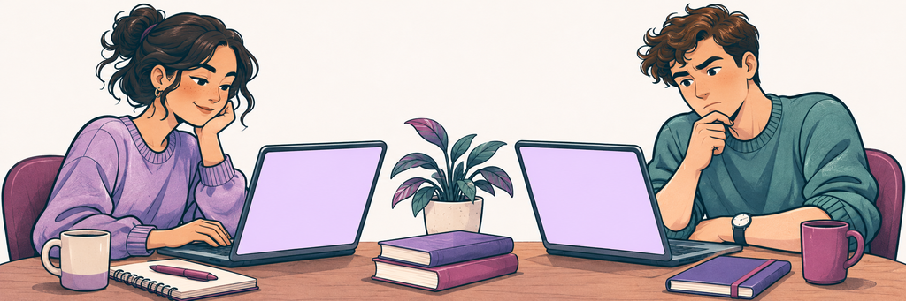

Alice World Bank report

```
CHE 1.314%
DEU 0.275%
FRA 0.262%
```

Bob same Git repository · same frozen data

```
ModuleNotFoundError:
No module named 'pandas'
```

Both students have exactly the same code and data.  
**What could explain the different results?**

Their execution environments differ: Bob’s executing Python is missing **pandas**. Check that interpreter and install its dependencies.

## Which Python is running?

**Goal** Identify the interpreter executing your code.

**Where** This browser slide. No local Python or Docker execution.

**Action** Predict → read the output → add the implementation line → read the modified output.

**Expected** Browser runtime details, not your laptop’s Python path.

**Hint / fallback** Add `print(platform.python_implementation())`. Expect `CPython`.

```python
import sys
import platform

print(sys.version)
print(sys.platform)
print(sys.executable)
```

**Expected:** Python 3.13.2 · `emscripten` · `/home/pyodide/this.program`.

**Add:** `print(platform.python_implementation())` → `CPython`.

## Your terminal has its own Python

```bash
python3 -c "import sys; print(sys.executable)"
python3 -m pip --version
```

Windows PowerShell: use `py -3.14` in place of `python3` here.

**Read both paths.** Are Python and pip associated with the same installation?

`python -m pip` runs pip through that Python. A browser path says nothing about your laptop’s packages.

## A · Diagnose the missing dependency

**Goal** Explain the failure before installing anything.

**Where** Terminal, inside the extracted `student-pack` folder.

**Action — macOS/Linux**

```bash
python3 -m venv .venv
.venv/bin/python report.py pipeline.py
```

**Windows PowerShell**

```powershell
py -3.14 -m venv .venv
.\.venv\Scripts\python.exe report.py pipeline.py
```

**Expected** Fresh environment: `No module named 'pandas'`.

**If blocked** Use that supplied error; identify the interpreter and missing package with a partner.

## What a virtual environment isolates

Installed Python**→**.venv  
project packages**→**report.py

`venv` creates a project-specific Python environment.

`pip` installs packages into the Python you select.

A venv isolates Python packages. It does not package the operating system or automatically include your data.

## A short recipe: requirements.txt

```
pandas==2.3.3
numpy==2.3.5
python-dateutil==2.9.0.post0
pytz==2025.2
tzdata==2025.2
six==1.17.0
```

`pandas` is used by the report; the other lines pin its dependencies.

Share this recipe, the Python version, code and data. Recreate `.venv` on each machine. Package pins alone do not fix the operating system.

## When a tiny dependency disappeared

22 MARCH 2016 JavaScript / npm · the left-pad incident

[figure not shown]

**273**packages unpublished

**≈ 2.5 hours**of disruption

Many thousands of projects affected.

How could a project suddenly stop building  
even though its developers had not changed the code?

An unchanged dependency chain can lead to a package that is **no longer downloadable**.

### Exact versions: guaranteed rebuild?

Pins identify versions.  
They cannot guarantee a download.

### Already-built Docker image: affected?

With packages included and no runtime fetch, it can keep running. A clean rebuild can still fail.

JavaScript incident; the dependency-availability problem also applies to Python.  
Source: [npm postmortem, 23 March 2016](https://blog.npmjs.org/post/141577284765/kik-left-pad-and-npm.html) · chain shown schematically

## Select the environment once

**macOS / Linux**

```bash
source .venv/bin/activate
```

**Windows PowerShell**

```powershell
.\.venv\Scripts\Activate.ps1
```

Both platforms, after activation:

```bash
python -c "import sys; print(sys.executable)"
```

**Expected:** a path inside `.venv`.

If activation is blocked, use `.venv/bin/python` or `.\.venv\Scripts\python.exe` instead of `python` in the next activity. No policy changes needed.

## B · Install and run the report

**Goal** Recreate the packages and run unchanged reporting code.

**Where** Same terminal and pack folder; `.venv` selected.

**Action — both platforms after activation**

```bash
python -m pip install -r requirements.txt
python report.py pipeline.py
python checks.py pipeline.py
python my-check.py pipeline.py
```

**Expected** CHE **1.314%**, DEU **0.275%**, FRA **0.262%**; `BASIC: 14/14` and `PRECISION PASS`.

**If blocked** Use the explicit `.venv` Python path from the previous slide. If installation fails, pair and compare `expected-report.txt`.

## Read the report as evidence

| Country | 2023 population | 2024 population | Increase | Growth |
| --- | --- | --- | --- | --- |
| CHE | 8,888,822 | 9,005,582 | 116,760 | 1.314% |
| DEU | 83,287,273 | 83,516,593 | 229,320 | 0.275% |
| FRA | 68,372,286 | 68,551,653 | 179,367 | 0.262% |

**Persons**, not thousands. Growth is displayed to three decimals.

Matching display values is useful evidence. It cannot prove full-precision calculations.

## Frozen data, reproducible input

**Goal** Keep the report’s input fixed.

**Where** A packaged snapshot in the browser’s virtual filesystem.

**Action** Run for `CHE`; change it to `FRA`; run again.

**Expected** CHE: **9,005,582**. FRA: **68,551,653** (2024, persons).

**Hint / fallback** Change only the country code. These saved values need no live API.

```python
import json

with open("data/raw/population-2023-2024.json") as f:
    payload = json.load(f)
country = "CHE"  # change to FRA
values = [r["value"] for r in payload[1]
          if r["countryiso3code"] == country
          and r["date"] == "2024"]
print(values[0])
```

**Expected:** CHE → `9005582`; change `country = "FRA"` → `68551653`.

## Reproducible does not mean correct

**Goal** Detect a repeatable calculation defect.

**Where** This browser slide; a small independent example.

**Action** Predict → read the output → remove early rounding → read the modified output.

**Expected** First: `AssertionError`. Corrected: `PASS`.

**Hint / fallback** Return the unrounded number. Compare with the correction beside this task.

```python
import math

def growth(before, after):
    rate = 100 * (after - before) / before
    return round(rate, 3)

assert math.isclose(
    growth(600, 700), 100 / 6,
    rel_tol=0, abs_tol=1e-9
), "AssertionError: rounded too early"
print("PASS")
```

**Before:** `AssertionError: rounded too early`.

**Correct:** `return rate` → `PASS`.

## Keep the independent check

```bash
python my-check.py pipeline.py
```

```
PRECISION CHE: expected 33.333333333333;
              actual   33.333333333333
PRECISION PASS (absolute tolerance 1e-9 percentage points)
```

The real output puts expected and actual on one line.

Re-run the same check after changing the environment. Never weaken an assertion to make an image pass.

## Checkpoint before the break

**Tell your neighbour:**

1. Which Python did you run?
2. What did the requirements file recreate?
3. What still depends on your laptop?

We can recreate Python packages. Python itself, system libraries and file inclusion still need attention. Next: package an execution environment with Docker.

## Docker adds a packaged runtime

Dockerfile  
recipe**→ build →**Image  
packaged filesystem**→ run →**Container  
execution

Inside our image: **Python + packages + report code + frozen data**.

Docker must be installed **and started** on the host.

Pair or analyse supplied outputs if Docker cannot run today.

## Three words, three different things

| Term | In this project | What you do |
| --- | --- | --- |
| Dockerfile | Text instructions | Read or edit |
| Image | Built environment, tagged `dcm-w10` | Build |
| Container | One execution from the image | Run |

Editing a Dockerfile does not update an existing image. **Rebuild, then run the new image.**

## Read the recipe: prepare Python

```
FROM python:3.14-slim
WORKDIR /app
COPY requirements.txt .
RUN python -m pip install --no-cache-dir -r requirements.txt
```

`FROM` selects a base. `WORKDIR` sets the working folder.

`COPY` brings a file from the build context into the image.

`RUN` executes **during the build**, installing the packages.

## Read the recipe: include the project

```
COPY *.py .
COPY data/ data/
CMD ["python", "report.py", "pipeline.py"]
```

`COPY data/ data/` includes the frozen data and check fixtures.

`CMD` supplies the default command **when a container runs**.

`RUN` prepares the image. `CMD` starts the report later. Building the image does not execute this report.

## The dot means this folder

```bash
docker build -t dcm-w10 .
```

Run from the extracted **student-pack** folder.

The final `.` is the build context: files Docker may copy.

`.dockerignore` excludes `.venv`, caches and Git metadata.

**Our data directory is deliberately included.**

## Build once; reuse the dependency layer

Base Python**→**Install requirements**→**Copy project

Code or data edits can reuse the earlier package-install layer.

**Before class:** build the complete reference image, not only `docker pull`.

Pulling Python caches the base. It does **not** install pandas. A successful full build prepares the actual dependency layer.

## C · Build → run → verify

**Goal** Execute and check the report inside an image.

**Where** Pack-folder terminal, Docker engine running. Both platforms.

**Action — supplied complete `Dockerfile`**

```bash
docker build -t dcm-w10 .
docker run --rm dcm-w10
docker run --rm dcm-w10 python checks.py pipeline.py
docker run --rm dcm-w10 python my-check.py pipeline.py
```

**Expected** Three report rows; `BASIC: 14/14`; `PRECISION PASS`.

**If blocked** Pair with a ready machine; analyse `supplied-output-analysis.md`. Record whether you executed or analysed.

## What does this command execute?

```bash
docker run --rm dcm-w10 python checks.py pipeline.py
```

The command after the tag replaces the image’s default `CMD`.

It runs the supplied check **inside the container**, against the included pipeline and fixtures.

A local `python checks.py` checks local files. It does not verify the contents of your image.

## A green build is not a green report

[figure not shown]

INSIDE THE IMAGE

Python**included**

pandas**included**

`pipeline.py`**included**

`report.py`**included**

`population-2023-2024.json`**MISSING**

`docker build`**SUCCESS**Instructions completed

`docker run`**FileNotFoundError**The report needs the frozen JSON

How can the image build successfully  
when an essential file is missing?

The build never read that input. The report tries to open it **at run time**. Inspect the recipe next.

Illustrated expected outcomes · not an execution log

## Inspect the defective recipe

```
FROM python:3.14-slim
WORKDIR /app
COPY requirements.txt .
RUN python -m pip install --no-cache-dir -r requirements.txt
COPY *.py .
# Something essential is missing here.
CMD ["python", "report.py", "pipeline.py"]
```

Which **one line** would you add? Do not change Python or tests.

## D · Repair the missing frozen data

**Goal** Prove that the repaired image contains usable inputs.

**Where** Pack-folder terminal and editor; both platforms.

**Action** Build and run the deliberately broken recipe:

```bash
docker build -f Dockerfile.broken -t dcm-w10-broken .
docker run --rm dcm-w10-broken
```

Add **`COPY data/ data/`** before `CMD` in `Dockerfile.broken`.

```bash
docker build -f Dockerfile.broken -t dcm-w10-fixed .
docker run --rm dcm-w10-fixed
docker run --rm dcm-w10-fixed python checks.py pipeline.py
docker run --rm dcm-w10-fixed python my-check.py pipeline.py
```

**Expected** Broken: missing-data `FileNotFoundError`; fixed: report, `14/14`, `PRECISION PASS`.

**If blocked** Compare `Dockerfile.reference`; pair or explain supplied outputs.

## What changed in the repair?

[figure not shown]

INSIDE THE IMAGE

Python**included**

pandas**included**

`pipeline.py`**included**

`report.py`**included**

`population-2023-2024.json`**included**

THE PACKAGING REPAIR

`COPY data/ data/`

Rebuild: the new image now contains the frozen JSON and its provenance.

Verify the repaired image · same commands as Activity D

```bash
docker run --rm dcm-w10-fixed
docker run --rm dcm-w10-fixed python checks.py pipeline.py
docker run --rm dcm-w10-fixed python my-check.py pipeline.py
```

**Build success**Instructions completed

**≠**

**Successful execution**The report ran

**≠**

**Verified behavior**Independent checks passed

## Ask AI for a bounded packaging edit

**You own the evidence:** inspect the diff, rebuild, run the report, then run both supplied checks inside that image.

A plausible Dockerfile is a proposal. Executed checks are evidence; even those checks have a stated scope.

## Choose the next diagnostic action

| Symptom | Next action |
| --- | --- |
| `No module named pandas` locally | Check Python path; install requirements there |
| Cannot connect to Docker daemon | Start Docker; pair if unavailable |
| Image builds; JSON missing at run | Inspect `COPY data/ data/`; rebuild |
| Report looks right; precision fails | Inspect calculation contract; keep assertion |

**Today’s priority:** complete the evidence sequence, not individual installation repair.

## Exit: reproduce, then verify

**Explain to a colleague:**

1. How do you recreate this project’s Python packages?
2. How does a Dockerfile become an executing report?
3. Why can an image build successfully and still fail?
4. What evidence verifies your repaired image?

`venv` → `pip` → `requirements.txt` · build → run → verify

Keep code, frozen input, provenance and independent checks together.